# Tarea 7 Estadística Multivariada

Hairo Ulises Miranda Belmonte

21 de Mayo del 2019

## EJERCICIO 1

**Investigue y describa la formulación de Análisis de Correspondencia mediante Mínimos Cuadrados Ponderados (MCP).**

El análisis de correspondencia se puede formular como un problema de mínimos cuadrados pesados al toma una matriz de correspondencia $\hat{P}={\hat{p}_{ij}}$, una matriz de rango reducido.

La formulación es la siguiente:

$$\Sigma_{i=1}^{I}\Sigma_{j=1}^{J}\frac{p_{ij}-\hat{p_{ij}}}{r_{i}c_{j}}=tr[(D_r^{\frac{-1}{2}}(P-\hat{P})D_c^{\frac{-1}{2}})(D_r^{\frac{-1}{2}}(P-\hat{P})D_c^{\frac{-1}{2}})']$$
esto es posible debido que $\frac{p_{ij}-\hat{p}_{ij}}{\sqrt{r_ic_j}}$ son los $i,j$-ésimos elementos de $(D_r^{\frac{-1}{2}}(P-\hat{P})D_c^{\frac{-1}{2}})$

Esto debido a que $rc'$ puede aproximar a la matrix $\hat{P}$

**Bibliografía**

- Johnson R. y Wichern D. (2014) Applied Multivariate Statistical Analysis. Cap 12. pp. 716-717.

Para describir la formulación de Análisis de Correspondencia mediante MCP, es necesario describir algunos conceptos de método de análisis de correspondencia multiple (MCA).

- MCA es una generalización del análisis de correspondencia simple; donde se tienen varias clases para las variables categoricas.
- Se tienen con dos aproximaciones para el MCA; el primero conocido como *multivariate indicator*; el segundo opera con la matriz de Burt.

Para propositos de MCP, solo se habla de la segunda aproximación. Se define una variable indicadorea, sea $Z_{ij}$ con valor de $1$, si el $j-esimo$ individuo pertenece a la $i-esima$ categoría, y con valor de $0$, en otro caso.

Definimos la operación mátricial $Z_{ij}Z_{j1}'$ como un elemento al cuadrado de la variable indicadora; entonces, sea B la matriz de Burt definida como $ZZ'$ con elementos $Z_{ij}Z_{j1}'$, siendo una matriz simétrica con el $q-esimo$ bloque diagonal como $nD_q$, con $n$ como el número de frecuencias totales, y $D_q$ la matriz diagonal de filas y columnas de masas de la $q-esima$ variables, y $q$ como el número de variables categoricas.

Los elementos de la matriz de Burt, y la matriz en si, es el análogo en caso discreto de la matriz de covarianzas donde se relacionan las $Q$ variables categoricas, y con el que MCA, desarrolla su análisis.

El problema de realizar la estimación anterior radica en el número de tablas de contigencia bidereccionales (*two-way*) que se generan $Q(Q-1)/2$, estas sobre la diagonal de la matriz $B$ de Burt, inclusive sabiendo que al ser una matriz simétrica y los elementos de la parte superiro de la diagonal son los elementos de la parte inferior de la diagonal de la matriz de Burt transpuesta.

Lo anterior permite hacer un análisis de correspondencia simple para cada $Q(Q-1)/2$ tablas, pero sería ineficiente violando los principios de eficiencia y reducción de dimensionalidad.

Para confrontar el problema, Greenacre (1988) propone un método de aproximación matricial a la matriz de Burt. el cual realiza lo siguiente:

- De manera simultanea ajusta todas las $Q(Q-1)/2$ tablasen una matriz tringula superior, sea $B$.
- Reduce el análisis de correspondencia simple de $N=N_{12}$ en el caso de que se tengan dos variables categoricas

La idea principal el apriximar la matrix Burt $B$ por $\hat{B}$, teniendo rango reducido que minimice el críterio de mínimos cuadrados pesados.

**Formulación**

$$n^{-1}trace(D^{\frac{-1}{2}}(B-B\hat{B})D^{-1}(B-B\hat{B})D^{\frac{-1}{2}})$$
donde:
$$D=QD_r$$
$Q$ veces la matriz diagonal $D_r$, de filas (o columnas) de las masas de $B$, y definidas tal que todos sus elementos sumen a uno.

Greenacre sugiere el uso de un algoritmo de mínimos cuadrados, como una medida alterna para obtener la aproximación $\hat{B}$; sin embargo, bajo esta formulación no logra garantizar el mínimo de la expresión sea logrado.

**Bibliografía**

- Izenman J (2008) Modern Multivarite Statistical Techniques. Springer Texts Statistics. Cap 17. pp. 661-662.

## EJERCICIO 2

Ejercicio 2. Considere una tabla de contingencia f de dimension n  n con elementos diferentes de cero sólo en la diagonal ¿ Cómo espera que sean las frecuencias relativas $r_i$ y $c_i$, para $i = i; : : : ; n$ ¿ Qué consecuencias tiene esto?

```r
library("tidyverse")
library("magrittr")
library("knitr")
library("kableExtra")
A <- c("A1", "A2", ".",".",".","Ar")
B <- c("B1", "B2", ".",".",".","Br")
Tabla <- matrix(0L, 6,6) %>% as.data.frame
colnames(Tabla) <- B
Tabla <- cbind(A,Tabla)
Tabla[1,2] <- "n11"
Tabla[2,2] <- "."
Tabla[3,2] <- "."
Tabla[4,2] <- "."
Tabla[5,2] <- "."

Tabla[1,3] <- "."
Tabla[2,3] <- "n22"
Tabla[3,3] <- "."
Tabla[4,3] <- "."
Tabla[5,3] <- "."

Tabla[3,4] <- "."
Tabla[4,5] <- "."
Tabla[5,6] <- "."
Tabla[6,7] <- "nrs"

Tabla %>% kable() %>% kable_styling()
```

| A | B1 | B2 | . | . | . | Br |
| --- | --- | --- | --- | --- | --- | --- |
| A1 | n11 | . | 0 | 0 | 0 | 0 |
| A2 | . | n22 | 0 | 0 | 0 | 0 |
| . | . | . | . | 0 | 0 | 0 |
| . | . | . | 0 | . | 0 | 0 |
| . | . | . | 0 | 0 | . | 0 |
| Ar | 0 | 0 | 0 | 0 | 0 | nrs |

Al tener una mátriz de contigencia con elementos solamente en $nij$ con $i=j$, se tiene como consecuencia que la frecuencia relativa para las filas $n_{i+}$, y la frecuencia relativa de las columnas $n_{+j}$, son las mismas.

Por lo tanto, las sumas de las frecuencias, sea $r=\Sigma_{i=1}^{r}n_{i+}$ y $c=\Sigma_{j=1}^{s}n_{+j}$, con $r=c$.

Esto sucede cuando una tabla de contigencia es simétrica, i.e, $N'=N$; implicando que el mapa de correspondencias pondra los pares de puntos filas y columnas como coincidentes, sugiriendo desviaciones a la independencia.

Por otro lado, con la matriz de Burt, los elementos que exprezan la relaciones de los pares, tendran elementos en las diagonales y de las matrices $D_r$ y $D_c$, y en las tablas de contigencia de las relaciones posiblementes cero, dando ligar a una posible independencia entre las variables y las clase.

**Bibliografía**

- Izenman J (2008) Modern Multivarite Statistical Techniques. Springer Texts Statistics. Cap 17. pp. 661-662.

## EJERCICIO 3

**Considere los datos dados en el archivo adjunto (FrenchFoodData.csv). El conjunto de datos consiste en el gasto promedio en ciertos alimentos para diferentes tipos de familias en Francia (manual workers D MA, employees D EM, managers D CA). Los datos se tomaron de Lebart, Morineau, y Fenelon (1982).**

**Dado que todas las variables son medidas en la misma unidad (Francos franceses), explique como es que pueden verse estos datos como una tabla de contigencia. Realice el análisis de correspondencia y compare los resultados con los obtenidos mediante PCA en el analisis de Hardle y Simar (2015, Chap. 11).**

```r
library("tidyverse")
library("magrittr")
library("readxl")
library("knitr")
library("kableExtra")
getwd()
```

```
## [1] "C:/Users/h_air/Desktop/Tarea 7"
```

```r
setwd("C:/Users/h_air/Desktop/Tarea 7")
datos <- read_excel("FrenchFoodData.xlsx")
names(datos)[1] <- "Nombre"
```

Tabla de contigencia del gasto promedio de ciertos alimentos en diferentes para diferentes tipos de familias en francia.

```r
datos %>% kable() %>% kable_styling()
```

| Nombre | bread | vegetables | fruits | meat | poultry | milk | wine |
| --- | --- | --- | --- | --- | --- | --- | --- |
| MA2 | 332 | 428 | 354 | 1437 | 526 | 247 | 427 |
| EM2 | 293 | 559 | 388 | 1527 | 567 | 239 | 258 |
| CA2 | 372 | 767 | 562 | 1948 | 927 | 235 | 433 |
| MA3 | 406 | 563 | 341 | 1507 | 544 | 324 | 407 |
| EM3 | 386 | 608 | 396 | 1501 | 558 | 319 | 363 |
| CA3 | 438 | 843 | 689 | 2345 | 1148 | 243 | 341 |
| MA4 | 534 | 660 | 367 | 1620 | 638 | 414 | 407 |
| EM4 | 460 | 699 | 484 | 1856 | 762 | 400 | 416 |
| CA4 | 385 | 789 | 621 | 2366 | 1149 | 304 | 282 |
| MA5 | 655 | 776 | 423 | 1848 | 759 | 495 | 486 |
| EM5 | 584 | 995 | 548 | 2056 | 893 | 518 | 319 |
| CA5 | 515 | 1097 | 887 | 2630 | 1167 | 561 | 284 |

Se reliza la representación de la tabla de contigencia.

```r
library("ca")
```

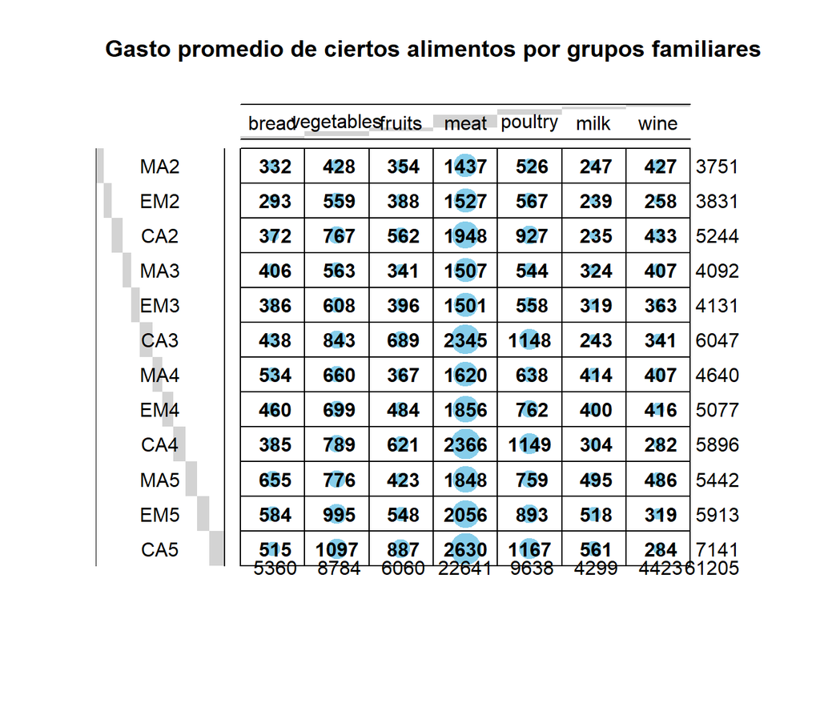

```r
library("gplots")
library("tidyverse")
Obs <- column_to_rownames(datos, var="Nombre")
# 2. Graph
balloonplot(t(as.table(as.matrix(Obs))), main ="Gasto promedio de ciertos alimentos por grupos familiares", xlab ="", ylab="",
            label = T, show.margins = T)
```

Donde los puntos de azul miden el grado de correlación entre las variables. Se puede observar mayor concentración entre todas las clases y la variable carne, indicando un consumo similar de la carne respecto a todas las familias. Una relaciónconsiderable entre las familias tipo 2 manager (CA2) y el consumo de aves; no obstante, no todas las clases y variables parecen estar relacionadas.

Podemos evaluar la independencia entre el grupo y los tipos de consummos de alimentos de las familias en Francia.

```r
chisq.test(Obs)
```

```
##
##  Pearson's Chi-squared test
##
## data:  Obs
## X-squared = 1290.4, df = 66, p-value < 2.2e-16
```

Ahora explicamos algunos aspectos de la matriz de contiegencia, los cuales son necesarios para el análisis.

La frecuencia total es de:

```r
n <-sum(Obs)
```

La matriz de correspondencias se presenta a continuación.

[figure not shown]

```r
library("ca")
library("gplots")
balloonplot(t(as.table(as.matrix(Obs/n))), main ="Hábitos de fumar en la organización", xlab="", ylab="",label = T, show.margins = T)
```

Se observa que los elementos de la tabla de contigencia fueron divididos entre la frecuencia total.

Las masas de los elementos fila son:

```r
v1 <- rowSums(Obs)
r <- v1/n
r
```

```
##        MA2        EM2        CA2        MA3        EM3        CA3
## 0.06128584 0.06259293 0.08567927 0.06685728 0.06749449 0.09879912
##        MA4        EM4        CA4        MA5        EM5        CA5
## 0.07581080 0.08295074 0.09633200 0.08891430 0.09660975 0.11667347
```

y masa de elementos columna de

```r
(c <- colSums(Obs)/n)
```

```
##      bread vegetables     fruits       meat    poultry       milk
## 0.08757454 0.14351769 0.09901152 0.36992076 0.15747079 0.07023936
##       wine
## 0.07226534
```

Perfiles por fila (Grupo familia)

```r
N_tot <- cbind(Obs,Total=rowSums(Obs))
N_tot <- rbind(N_tot,Total=colSums(N_tot))
N_tot
```

```
##       bread vegetables fruits  meat poultry milk wine Total
## MA2     332        428    354  1437     526  247  427  3751
## EM2     293        559    388  1527     567  239  258  3831
## CA2     372        767    562  1948     927  235  433  5244
## MA3     406        563    341  1507     544  324  407  4092
## EM3     386        608    396  1501     558  319  363  4131
## CA3     438        843    689  2345    1148  243  341  6047
## MA4     534        660    367  1620     638  414  407  4640
## EM4     460        699    484  1856     762  400  416  5077
## CA4     385        789    621  2366    1149  304  282  5896
## MA5     655        776    423  1848     759  495  486  5442
## EM5     584        995    548  2056     893  518  319  5913
## CA5     515       1097    887  2630    1167  561  284  7141
## Total  5360       8784   6060 22641    9638 4299 4423 61205
```

Perfiles por fila (Grupo familia) matriz de contigencia

```r
perfil_fila <- prop.table(as.matrix(N_tot[,-ncol(N_tot)]),1) # Row prof

perfil_fila
```

```
##            bread vegetables     fruits      meat   poultry       milk
## MA2   0.08850973  0.1141029 0.09437483 0.3830978 0.1402293 0.06584911
## EM2   0.07648134  0.1459149 0.10127904 0.3985904 0.1480031 0.06238580
## CA2   0.07093822  0.1462624 0.10717010 0.3714722 0.1767735 0.04481312
## MA3   0.09921799  0.1375855 0.08333333 0.3682796 0.1329423 0.07917889
## EM3   0.09343985  0.1471799 0.09586057 0.3633503 0.1350763 0.07722101
## CA3   0.07243261  0.1394080 0.11394080 0.3877956 0.1898462 0.04018522
## MA4   0.11508621  0.1422414 0.07909483 0.3491379 0.1375000 0.08922414
## EM4   0.09060469  0.1376797 0.09533189 0.3655702 0.1500886 0.07878669
## CA4   0.06529851  0.1338195 0.10532564 0.4012890 0.1948779 0.05156038
## MA5   0.12036016  0.1425946 0.07772878 0.3395810 0.1394708 0.09095921
## EM5   0.09876543  0.1682733 0.09267715 0.3477084 0.1510232 0.08760359
## CA5   0.07211875  0.1536199 0.12421230 0.3682958 0.1634225 0.07856043
## Total 0.08757454  0.1435177 0.09901152 0.3699208 0.1574708 0.07023936
##             wine
## MA2   0.11383631
## EM2   0.06734534
## CA2   0.08257056
## MA3   0.09946237
## EM3   0.08787219
## CA3   0.05639160
## MA4   0.08771552
## EM4   0.08193815
## CA4   0.04782904
## MA5   0.08930540
## EM5   0.05394893
## CA5   0.03977034
## Total 0.07226534
```

El perfil de las familia es

```r
prop.table(as.matrix(N_tot[,-ncol(N_tot)]),1)[1,] # Row prof
```

```
##      bread vegetables     fruits       meat    poultry       milk
## 0.08850973 0.11410291 0.09437483 0.38309784 0.14022927 0.06584911
##       wine
## 0.11383631
```

El perfil promedio del consumo en alimentos es

```r
prop.table(as.matrix(N_tot[,-ncol(N_tot)]),1)[nrow(Obs)+1,] # Row prof
```

```
##      bread vegetables     fruits       meat    poultry       milk
## 0.08757454 0.14351769 0.09901152 0.36992076 0.15747079 0.07023936
##       wine
## 0.07226534
```

Para el análisis se comparan los perfiles de los grupos familiares entre ellos y/o con el perfil de alimentos (razones de contingencia).

```r
prop.table(as.matrix(N_tot[,-ncol(N_tot)]),1)[1,] / prop.table(as.matrix(N_tot[,-ncol(N_tot)]),1)[nrow(Obs)+1,]
```

```
##      bread vegetables     fruits       meat    poultry       milk
##  1.0106787  0.7950442  0.9531702  1.0356214  0.8905097  0.9374958
##       wine
##  1.5752547
```

El p erfiles de columna (comida)

```r
N_tot
```

```
##       bread vegetables fruits  meat poultry milk wine Total
## MA2     332        428    354  1437     526  247  427  3751
## EM2     293        559    388  1527     567  239  258  3831
## CA2     372        767    562  1948     927  235  433  5244
## MA3     406        563    341  1507     544  324  407  4092
## EM3     386        608    396  1501     558  319  363  4131
## CA3     438        843    689  2345    1148  243  341  6047
## MA4     534        660    367  1620     638  414  407  4640
## EM4     460        699    484  1856     762  400  416  5077
## CA4     385        789    621  2366    1149  304  282  5896
## MA5     655        776    423  1848     759  495  486  5442
## EM5     584        995    548  2056     893  518  319  5913
## CA5     515       1097    887  2630    1167  561  284  7141
## Total  5360       8784   6060 22641    9638 4299 4423 61205
```

El perfil columna (comida) con la matriz de contigencia es

```r
perfil_columna <-   prop.table(as.matrix(N_tot[-nrow(N_tot),]),2) # Col prof

perfil_columna
```

```
##          bread vegetables     fruits       meat    poultry       milk
## MA2 0.06194030 0.04872495 0.05841584 0.06346893 0.05457564 0.05745522
## EM2 0.05466418 0.06363843 0.06402640 0.06744402 0.05882963 0.05559432
## CA2 0.06940299 0.08731785 0.09273927 0.08603860 0.09618178 0.05466388
## MA3 0.07574627 0.06409381 0.05627063 0.06656066 0.05644325 0.07536636
## EM3 0.07201493 0.06921676 0.06534653 0.06629566 0.05789583 0.07420330
## CA3 0.08171642 0.09596995 0.11369637 0.10357316 0.11911185 0.05652477
## MA4 0.09962687 0.07513661 0.06056106 0.07155161 0.06619631 0.09630147
## EM4 0.08582090 0.07957650 0.07986799 0.08197518 0.07906205 0.09304489
## CA4 0.07182836 0.08982240 0.10247525 0.10450068 0.11921560 0.07071412
## MA5 0.12220149 0.08834244 0.06980198 0.08162184 0.07875078 0.11514306
## EM5 0.10895522 0.11327413 0.09042904 0.09080871 0.09265408 0.12049314
## CA5 0.09608209 0.12488616 0.14636964 0.11616095 0.12108321 0.13049546
##           wine      Total
## MA2 0.09654081 0.06128584
## EM2 0.05833145 0.06259293
## CA2 0.09789735 0.08567927
## MA3 0.09201899 0.06685728
## EM3 0.08207099 0.06749449
## CA3 0.07709699 0.09879912
## MA4 0.09201899 0.07581080
## EM4 0.09405381 0.08295074
## CA4 0.06375763 0.09633200
## MA5 0.10988017 0.08891430
## EM5 0.07212299 0.09660975
## CA5 0.06420981 0.11667347
```

con razones de contingencia

```r
prop.table(as.matrix(N_tot[-nrow(N_tot),]),2)[,1] / prop.table(as.matrix(N_tot[-nrow(N_tot),]),2)[,ncol(Obs)+1]
```

```
##       MA2       EM2       CA2       MA3       EM3       CA3       MA4
## 1.0106787 0.8733284 0.8100324 1.1329546 1.0669749 0.8270966 1.3141514
##       EM4       CA4       MA5       EM5       CA5
## 1.0346007 0.7456334 1.3743738 1.1277870 0.8235127
```

A continuación la exploración de los residuales estandarizados de cada casilla y su contribución. Se utiliza la prueba chi cuadrada previa.

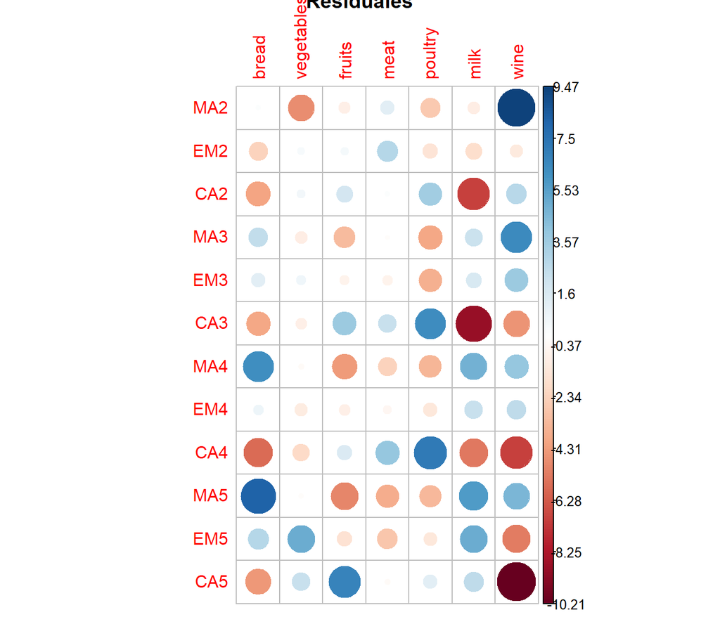

```r
library("corrplot")
chisq <- chisq.test(Obs)
corrplot(chisq$residuals, is.cor = FALSE, main='Residuales')
```

Ahora se observa la contribución.

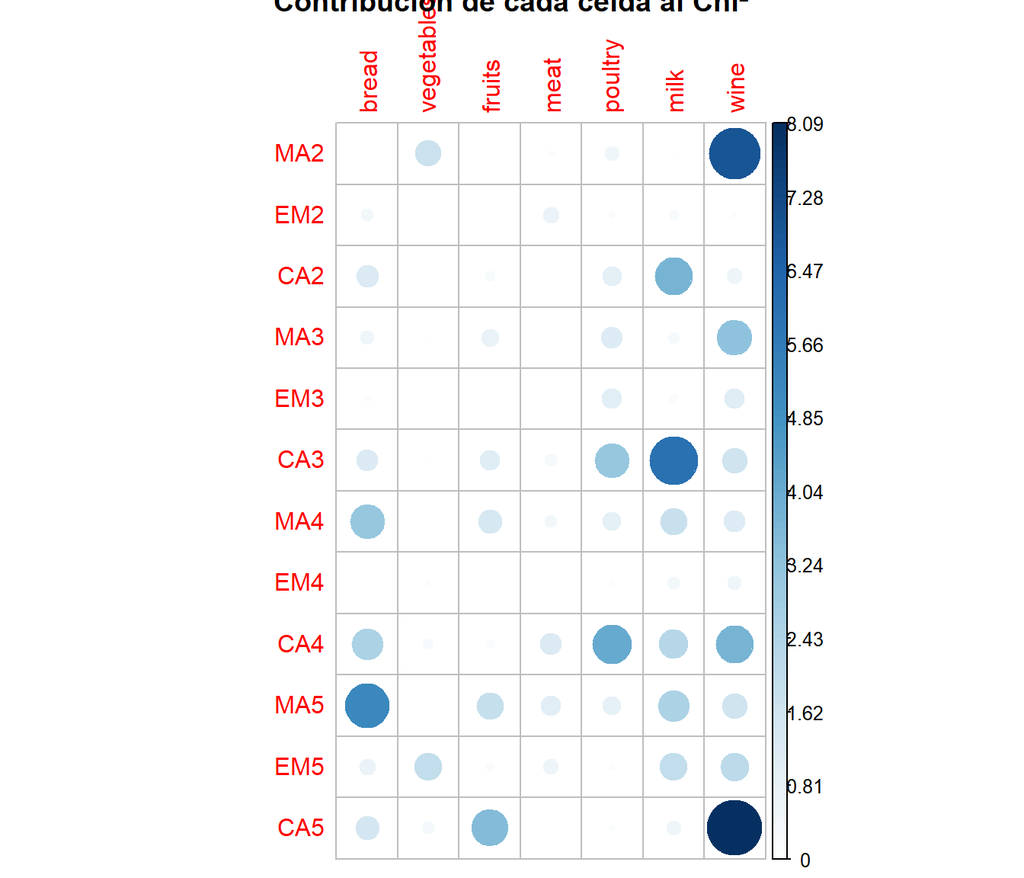

```r
# Contibución
contrib <- 100*chisq$residuals^2/chisq$statistic
corrplot(contrib, is.cor = FALSE, main='Contribución de cada celda al Chi²')
```

Ahora pasamos a realizar el análisis de correspondencia, lo anterior nos dió un panorama de la tabla de contigencia.

Para determinar el número de dimensiones se utiliza el screeplot

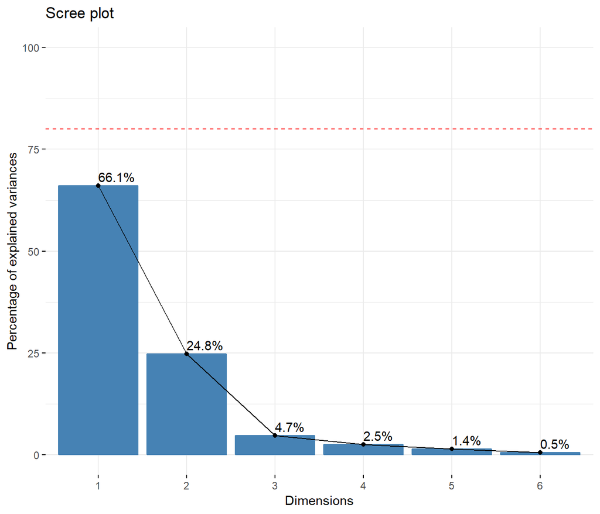

```r
library("FactoMineR")
library("factoextra")
res.ca <- CA(Obs, graph = FALSE)
fviz_screeplot(res.ca, addlabels = TRUE, ylim = c(0, 100))+
 geom_hline(yintercept=80, linetype=2, color="red")
```

Si se observa, la figura del codo se presenta en la segunda dimensión; acumulando el porcentaje de la varianza explicada de los dos primeros valores propios se tiene un total de $90.9\%$ de la varianza explicada.

Seimplementa el gráfico biplot para ver la relación entre las familias y el consumo de alimentos.

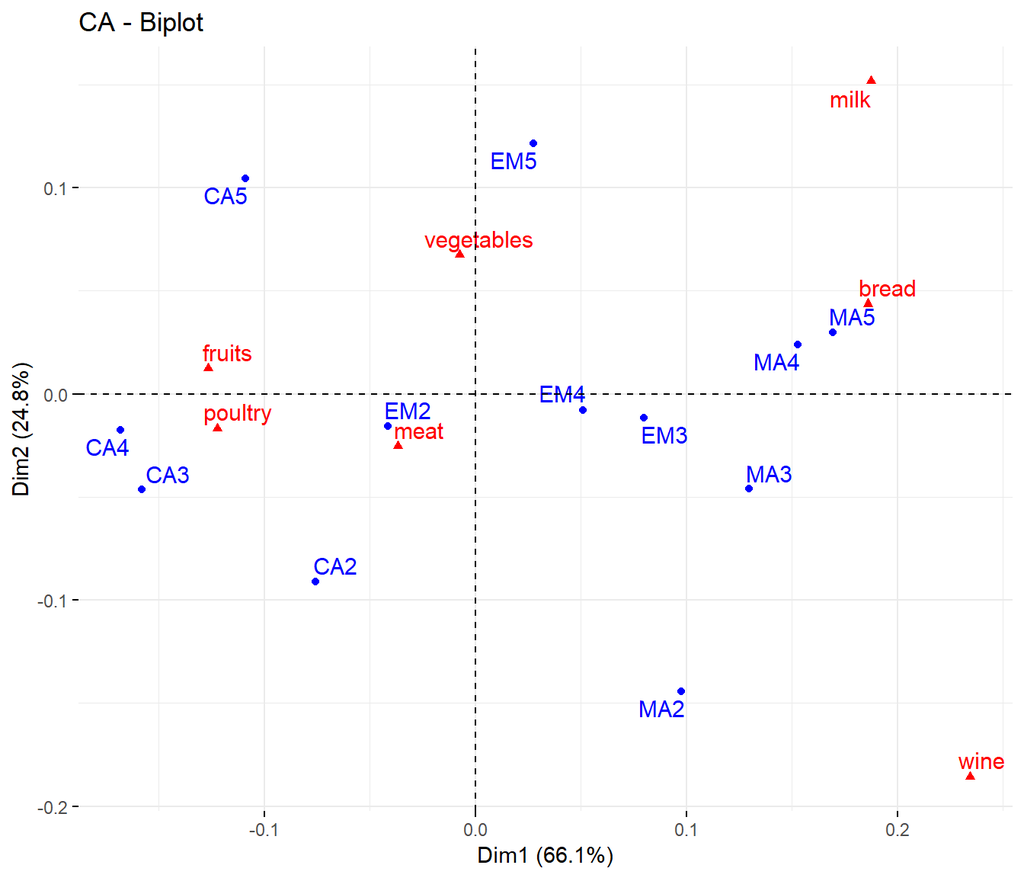

```r
fviz_ca_biplot(res.ca, repel = TRUE)
```

Se puede observar que la familias de tipo EM5 se relacionan con el consumo de vegetales; las MA5 y MA4, se relacionan con el consumo de pan; EM2 y CA2, tienden a consumir más carnes y algo de aves: CA4, se relaciona con el consumo de frutas; CA5,presenta una relación ligera con el consumo de frutas y vegetales; y los tipos de familias MA2 y MA3, son los que más se acercan a la relación con el vino, por ende, son aquellas familias que consumen más el vino.

Otra forma de interpretar los resultaso es; las familias que se encuentran en el lado positivo de la dimensión uno; i.e, EM5,EM3, MA3,MA2, MA4 y MA5, son familias que tienden a consuir menos las carnes, posiblementes son aquellos que tienden a al consumo de comida vegetariana, con la excepción de la leche; por otro lado, las familias EM2, CA2 y CA3,CA4, son familias cuyas referencias en el consumo de comidas son más relacionadas con la carne.

Ahora veamos las relaciones por separado, primero entre las familias.

```r
row <- get_ca_row(res.ca)
```

vemos las coordenadas por fila

```r
head(row$coord)
```

```
##           Dim 1       Dim 2        Dim 3        Dim 4        Dim 5
## MA2  0.09772547 -0.14432741  0.041776023 -0.020647735  0.015599477
## EM2 -0.04140225 -0.01580041  0.031878479 -0.007453572 -0.047968276
## CA2 -0.07560003 -0.09090565 -0.009271686  0.051228760  0.005436086
## MA3  0.12975203 -0.04607564  0.015087184 -0.004160933 -0.015804468
## EM3  0.07976771 -0.01154798  0.031155176  0.019453726 -0.009708791
## CA3 -0.15805731 -0.04644345 -0.033639633  0.009261494  0.007019849
```

se realiza la visualización

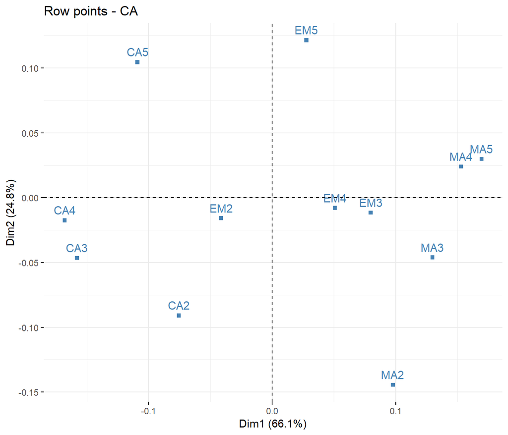

```r
fviz_ca_row(res.ca, col.row="steelblue", shape.row = 15)
```

*Representación de la calidad de las filas en las dimensiones.*

Observamos si los puntos en dos dimensiones están bien representados.

Se utiliza la medida Cos2 ppara medir el grado de asos entre filas o columnas en un eje en particulas.

Los puntos Cos2 para las filas son.

```r
head(row$cos2, 4)
```

```
##         Dim 1      Dim 2       Dim 3        Dim 4       Dim 5
## MA2 0.2911549 0.63504767 0.053206274 0.0129973112 0.007418716
## EM2 0.3115813 0.04537959 0.184722060 0.0100983993 0.418246017
## CA2 0.3375593 0.48807645 0.005077192 0.1550007543 0.001745335
## MA3 0.8643764 0.10899768 0.011686675 0.0008889064 0.012824321
```

Estos valores se encuentran entre 0 y 1, su suma para todas las filas entodas las dimensiones CA es igual a uno.

Ahora, se realiza la visualización

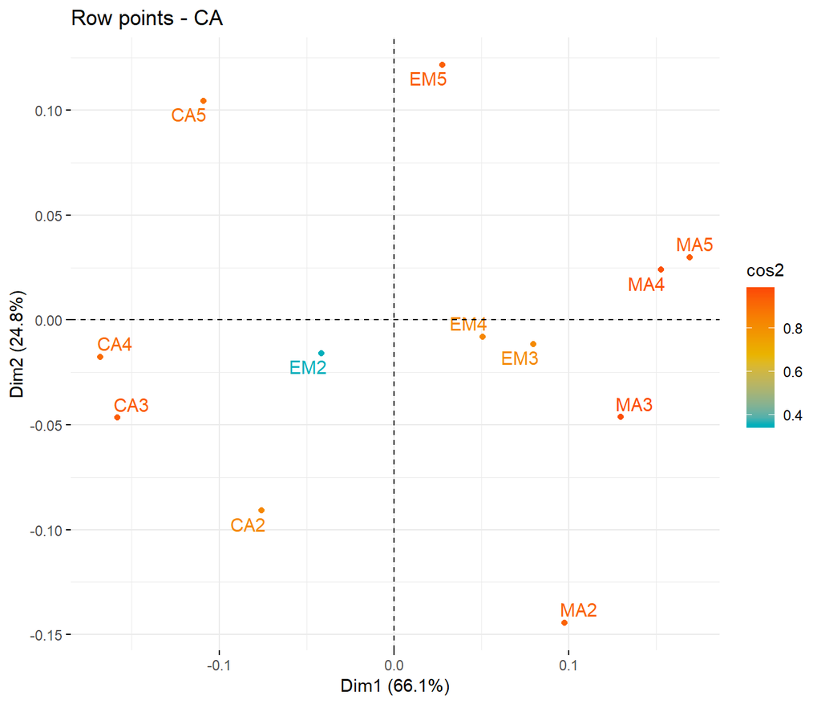

```r
fviz_ca_row(res.ca, col.row = "cos2",
             gradient.cols = c("#00AFBB", "#E7B800", "#FC4E07"),
             repel = TRUE)
```

Si un elemento de la fila se encuentra bien representado por las dos dimensiones, la suma de cos2 debe se cercana a uno. Se puede ver que solo para el tipo de familia EM2, la representación en dos dimensiones no es la mejor; sin embargo para todas las demás familias (filas), dos dimensiones explican de forma correcta.

Ahora, vemos la contribución de las filas a las dimensiones.

```r
head(row$contrib)
```

```
##          Dim 1      Dim 2      Dim 3      Dim 4      Dim 5
## MA2  4.2024220 24.4339805 10.7251952  5.0148666  5.0067832
## EM2  0.7703659  0.2990877  6.3783931  0.6674344 48.3517326
## CA2  3.5159584 13.5517041  0.7385571 43.1576557  0.8500156
## MA3  8.0816682  2.7166131  1.5260050  0.2221696  5.6064386
## EM3  3.0835181  0.1722728  6.5693072  4.9026205  2.1358814
## CA3 17.7217349  4.0788565 11.2110536  1.6265578  1.6345084
```

Filas que contibuyan más a la dimensión 1 y 2 son las más importantes en la explicación de la variabilidad del conjunto de datos. Filas que no contrubuyan de manera considerable a las dimensiones serán las menos importantes.

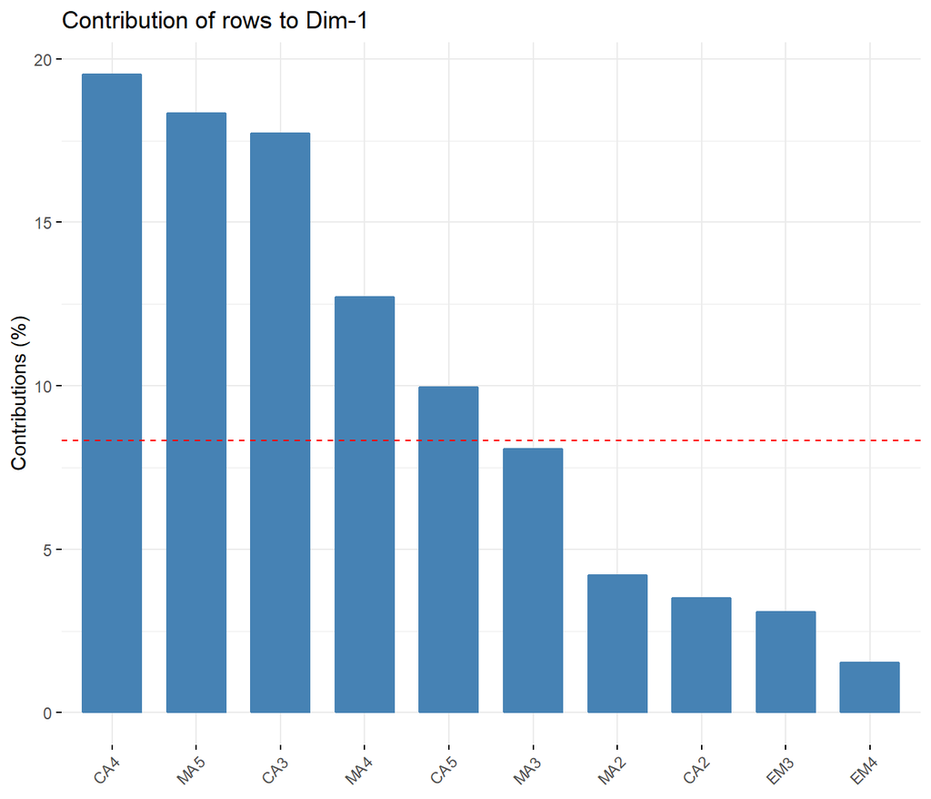

```r
fviz_contrib(res.ca, choice = "row", axes = 1, top = 10)
```

La linea roja indica el valor promedio, donde uno espera que la distribución sea uniforme ante los elementos de la filas. Podemos ver que las familias que más contribuyen a la primera dimensión son CA4,MA5, CA3 y MA4.

Para la segunda dimensión se tiene:

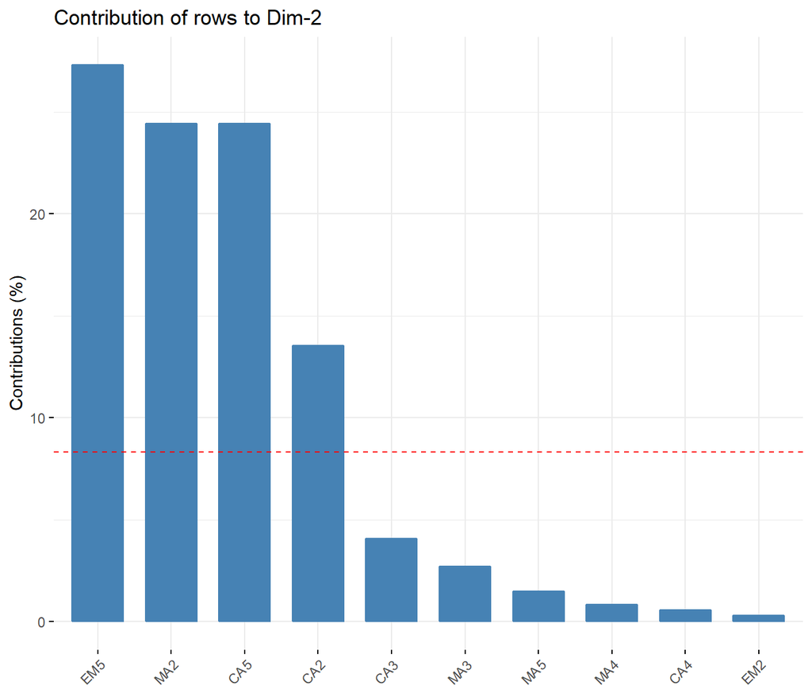

```r
fviz_contrib(res.ca, choice = "row", axes = 2, top = 10)
```

Las familias que más contrubuyen en está dimesión, la dos, son la EM5,MA2 CA5,CA2; de esta manera, las familias tipo manager CA, empleados manuales MA y EM5 son aquellos que explican más a la contribución en las dimensiones y por ende las que mejor explican la variabilidad en el consumo de alimentos.

Con base lo anterior uno puede no considerar a las familias trabajadoreas (EM), sin contar EM5, para este análisis del consumo de alimentos, ya que no aportan mucho a la representación de las dimensiones y por ende a la variabilidad de los datos.

Lo anterior lo se puede representár en dos dimensiones, y podemos ver mejor como las familias empleadas (EM), no tienen mucha contribución en el consumo de los alimentos.

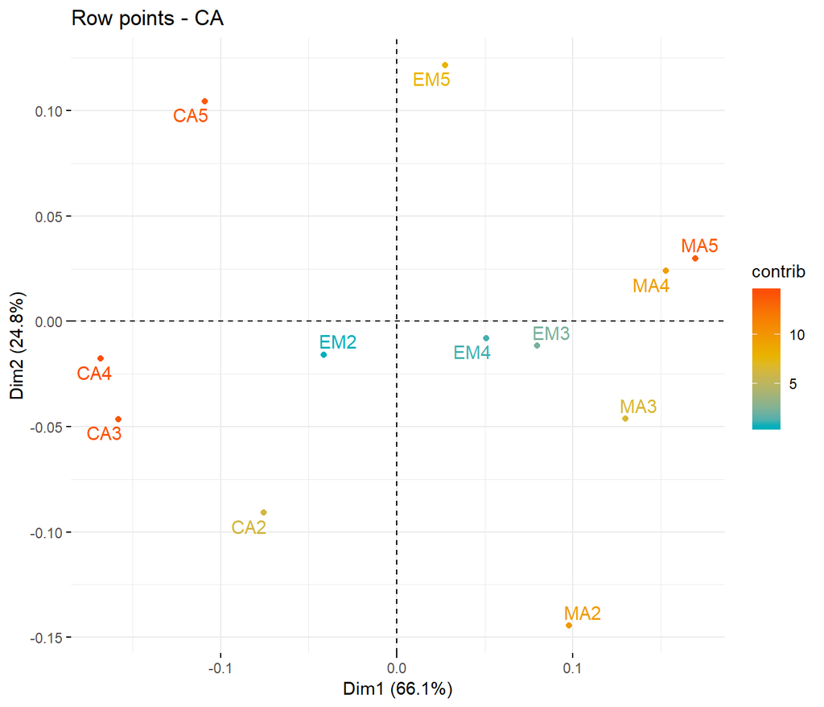

```r
fviz_ca_row(res.ca, col.row = "contrib",
             gradient.cols = c("#00AFBB", "#E7B800", "#FC4E07"),
             repel = TRUE)
```

Para concluir, realizamos el mismo análisis de los puntos en las filas pero para las columnas; i.e., el tipo de alimentos que consumen las familias.

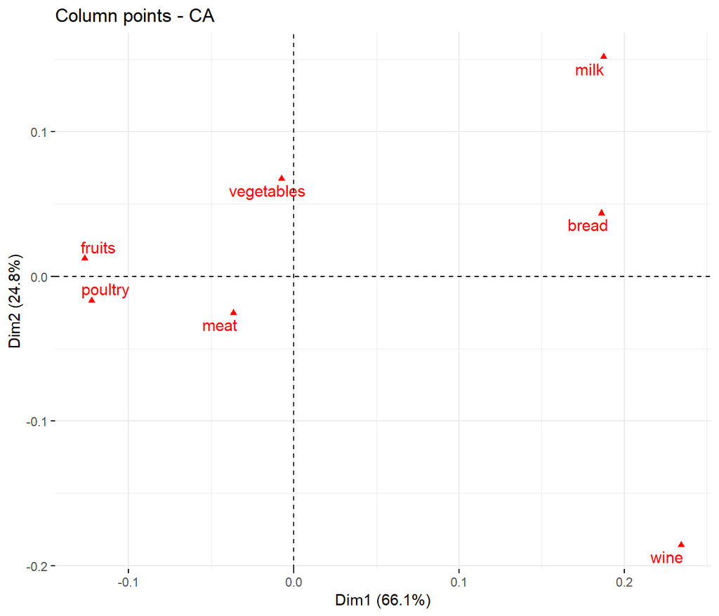

```r
fviz_ca_col(res.ca, repel = TRUE)
```

En la gráfica de abajo se tiene la calidad de la representación de las variables (columnas), en las dos dimensiones.

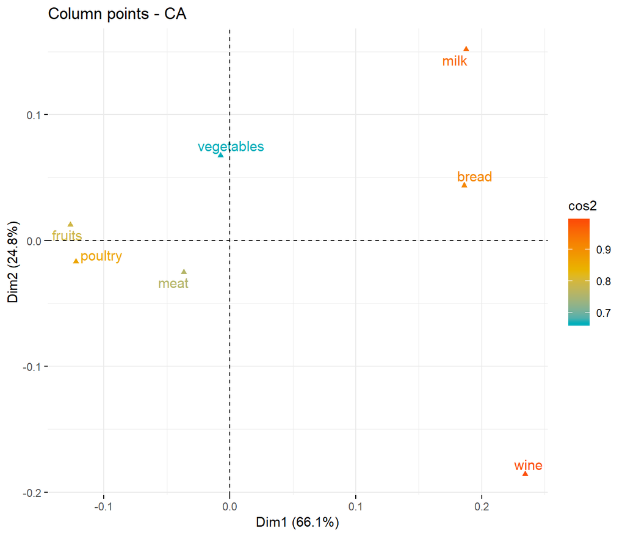

```r
fviz_ca_col(res.ca, col.col = "cos2",
             gradient.cols = c("#00AFBB", "#E7B800", "#FC4E07"),
             repel = TRUE)
```

Respecto a la contribución de las columnas a la variabilidad de los datos se tiene el siguiente gráfico.

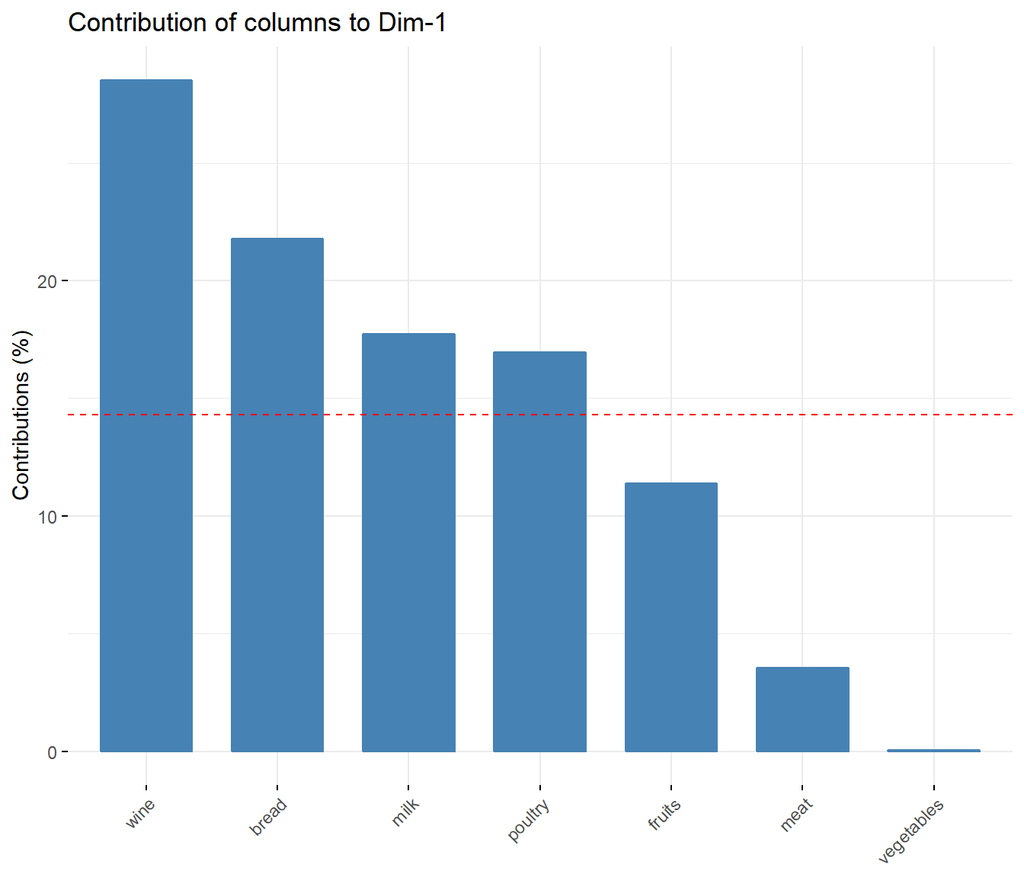

```r
fviz_contrib(res.ca, choice = "col", axes = 1, top = 10)
```

Se observa que las columnas de los alimentos vino y pan son los que más contribuyen a la primera dimensión.

Para la segunda dimensión los alimentos vino y leche son los que contribuyen más.

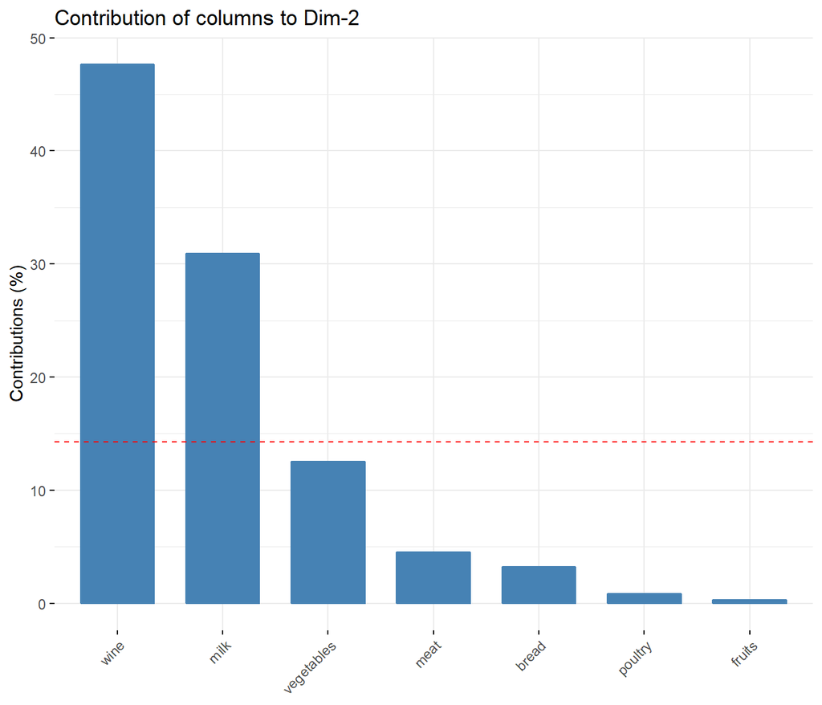

```r
# Total contribution to dimension 1 and 2
fviz_contrib(res.ca, choice = "col", axes = 2, top = 10)
```

De está manera, al ver el gráfico en 2D, se observa mejor lo anterior, el vino es el que más contribuye a la variabilidad de los datos; los que menos aportan a esta variabilidad son; los vegetales y las carnes, siendo variables que se puedan extraer del análisis.

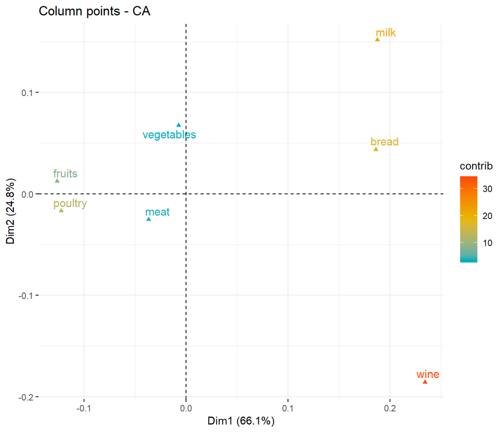

```r
fviz_ca_col(res.ca, col.col = "contrib",
             gradient.cols = c("#00AFBB", "#E7B800", "#FC4E07"),
             repel = TRUE)
```

Se utilizan los resultados del Hardle y Simar (2015, Chap. 11, con el fin de contrastar resultaod; para esto, se toman las imagenes de los resultados de libro al aplicar PCA en el conjunto de observaciones.

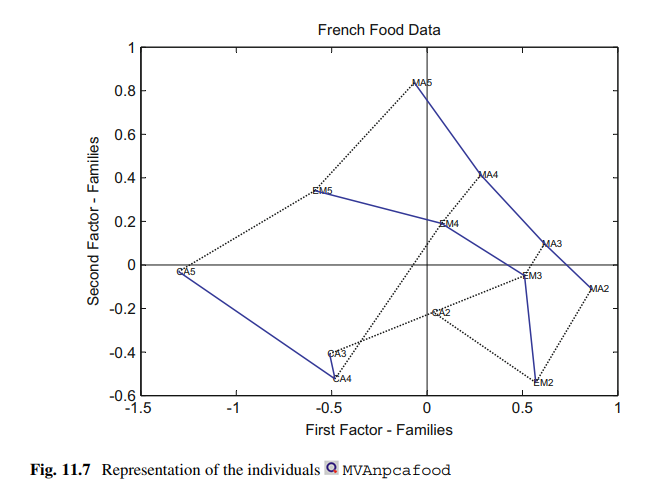

```r
library("png")
library("magick")
imagen <-  image_read("C:/Users/h_air/Desktop/Tarea 7/p1.png")
imagen
```

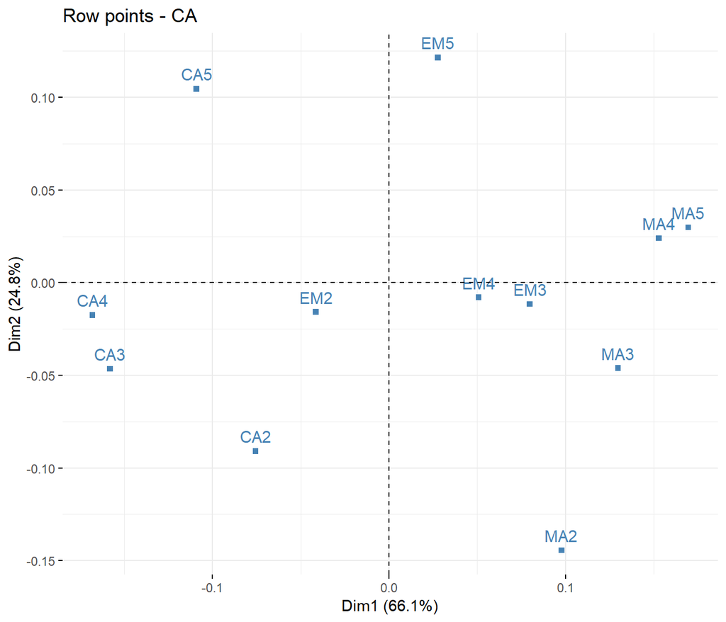

```r
fviz_ca_row(res.ca, col.row="steelblue", shape.row = 15)
```

Contrastando los agrupamientos vemos la similaridad entre las fammilias tipo CA4 y CA3, los cuales se representan tanto en PCA como en CA; sin embargo, el primero se representa sobre la segunda componentes; y en CA sobre su primera dimensión.

El patron CA4,CA3,CA3,EM2, también se expreza bajo los dos métodos;el agrupamiento MA4, MA5, y la agrupación EM3 con EM4, en PCA tienden ser más disimilares, no obstante entre ellos sigue la misma estructura, siendo paralelas.

En general, las relaciones entre las famiias se preserva bajo los dos métodos, con la sola diferencia cambios en las rotaciones de las observaciones.

Ahora, respecto a las variables (columnas)

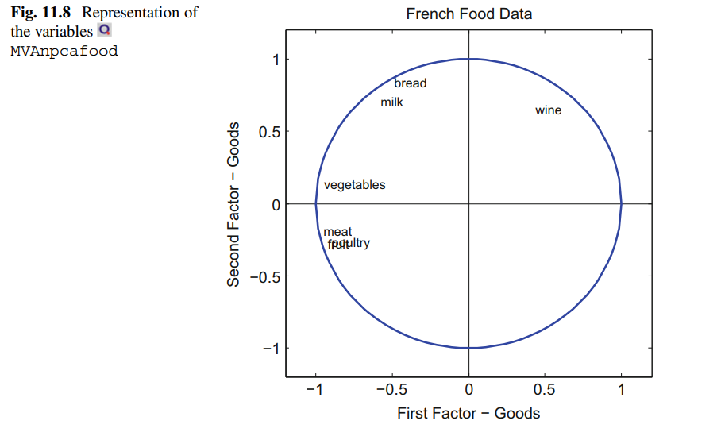

```r
library("png")
library("magick")
imagen2 <-  image_read("C:/Users/h_air/Desktop/Tarea 7/p2.png")
imagen2
```

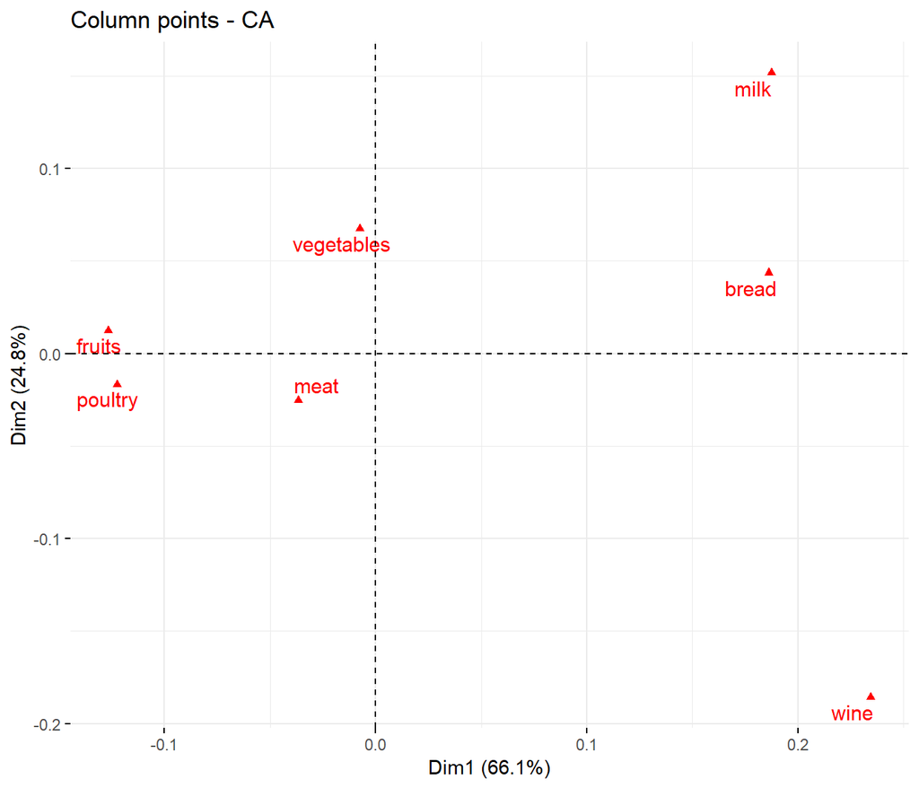

```r
fviz_ca_col(res.ca, repel = TRUE)
```

En cocnlusión realizar el análisis CA y PCA, traen consigo resultados similares; i.e., detectan las mismas agrupaciones del consumo de unidad por alimento y el tipo de familia que se consedera en el estudio.